# To Be Or Not To Be: The Ivory-Billed Woodpecker

Brianna Saylor

2025-11-12

## Distribution

[interactive chart not shown]

The Ivory-Billed Woodpecker (IBWO) was an iconic bird of the south. It’s nickname was the Lord God Bird due to its humongous size. At 20 inches tall with at 30 inch wingspan it was the largest woodpecker the US and the third largest in the world. It’s most iconic feature is it’s ivory bill.

The bird lived in dense, old growth forests mostly in the swamp lands of the south. Heavy logging in the early 20th century decimated their population. In 1940, it was estimated only 22-24 birds remained in the US. The last universally accepted sighting occurred in 1944. Severe population declines causes it to be listed as endangered in 1967 shortly after the creation of the Endangered Species Act. The last accepted sighting of the Cuban population occurred in 1987. Reported sightings still occur to this day giving rise to its other nickname the Ghost Bird.

The IBWO is surrounded by a lot of controversy. In 2021 the USFWS proposed the bird be removed from the endangered species list due to extinction. However, they have faced significant backlash and public commentary claiming the species still exists due to continued isolated sightings of the Ghost Bird. Some claim these sightings are a case of mistaken identity. The IBWO appears morphologically similar to the Pileated Woodpecker and its call sounds similar to some calls made by Blue Jays. Others are adamant the Ghost Bird is still out there somewhere. Due to high tension, the USFWS has kept the IBWO on the endangered species list and is continuing to explore the potential for its existence.

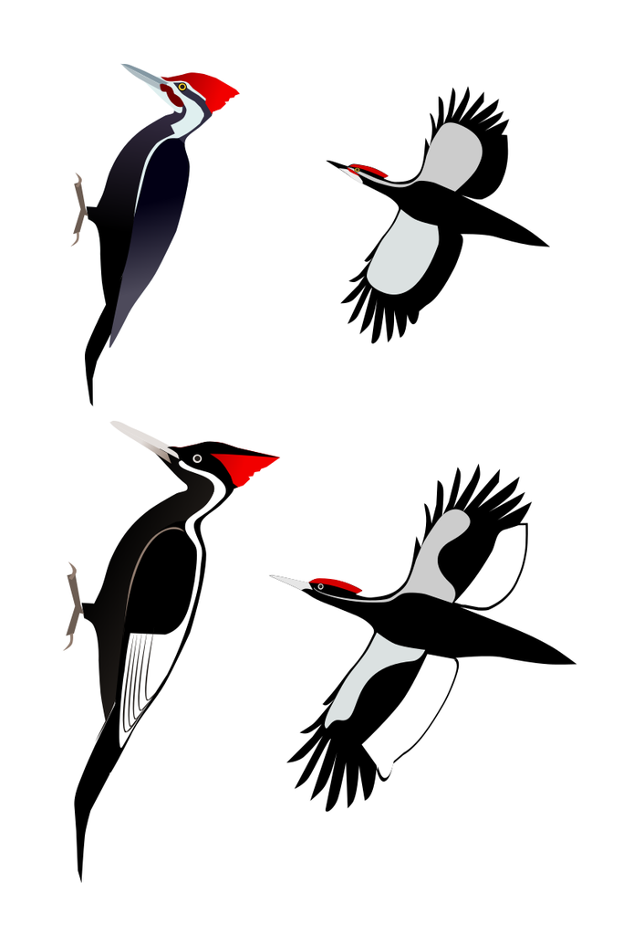

Pileated Woodpecker on top and Ivory-Billed Woodpecker on bottom.

Ornithologists have been able to reconstruct the range of the IBWO through historical records:

```r
pilo.dismo <- gbif("campephilus", species = "principalis", ext = c(-130, -70, 10, 50,
                    geo = TRUE, download = TRUE, removeZeros = TRUE))
pilo.dismo <- pilo.dismo[pilo.dismo$lat != 27.57333, ] # remove occurrence point in the ocean
```

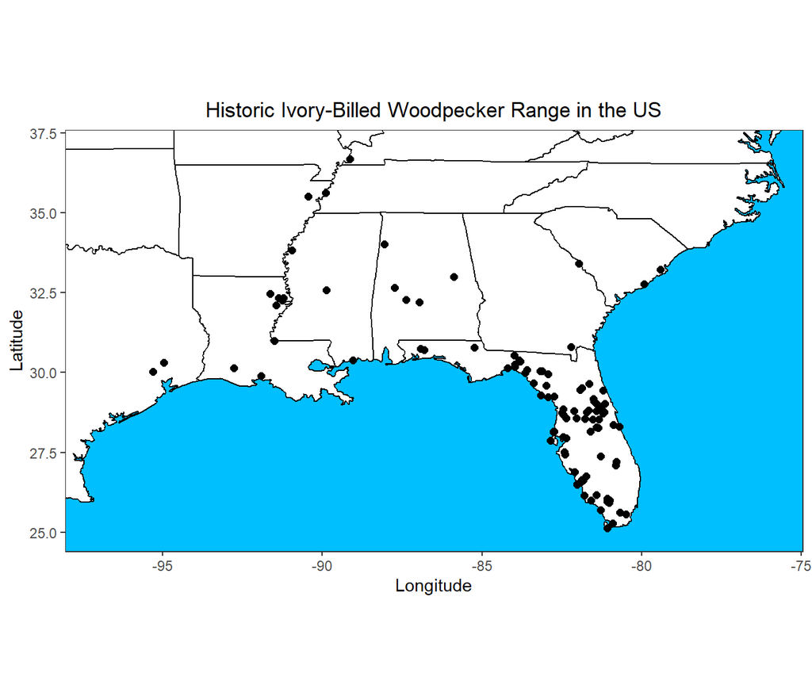

```r
us <- map_data("state")

ggplot() +
  geom_polygon(data = us, aes(x=long, y = lat, group = group),
               fill = "white", color="black") +
  geom_point(data = pilo.dismo, aes(x=lon, y=lat), size = 2) +
  xlab("Longitude") + ylab("Latitude") +
  coord_fixed(xlim = c(-97,-76), ylim = c(25,37)) +
  xlab("Longitude") + ylab("Latitude") + ggtitle("Historic Ivory-Billed Woodpecker Range in the US") +
  theme_bw() + theme(plot.title = element_text(hjust = 0.5)) +
  theme(panel.grid.major = element_blank(),
        panel.grid.minor = element_blank(),
        panel.background = element_rect(fill = "deepskyblue"))
```

## Occurrence Probability

```r
# bioclim <- getData(name = "worldclim", res = 2.5, var = "bio", path = "./")
# getData no long works

bioclim <- worldclim_global(var = "bio", res = 10, path = "./")
bioclim <- bioclim[[c(1, 3, 10, 11, 12, 16, 17)]] # select only the variable we are interested in
names(bioclim) <- c("Ann Mean Temp","Isothermality", "Mean Temp Warmest Qtr","Mean Temp Coldest Qtr",
                    "Annual Precip","Precip Wettest Qtr","Precip Driest Qtr")

bio.extent <- extent(x = c(
  min(pilo.rgbif.df$x),
  max(pilo.rgbif.df$x),
  min(pilo.rgbif.df$y),
  max(pilo.rgbif.df$y)))

bioclim.extent <- crop(x = bioclim, y = bio.extent)

bioclim_raster <- raster::stack(bioclim.extent) # convert SpatRaster to Raster so dismo can handle it

bioclim.model <- bioclim(x = bioclim_raster, p = cbind(pilo.rgbif.df$x,pilo.rgbif.df$y))
presence.model <- dismo::predict(object = bioclim.model,
                                 x = bioclim_raster,
                                 ext = bio.extent)
```

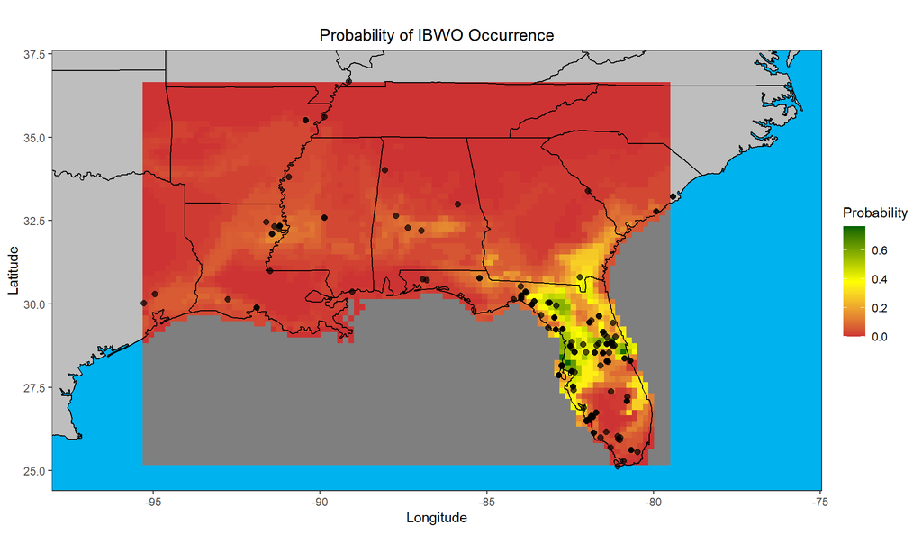

```r
rasterVis::gplot(presence.model) +
  geom_polygon(data = us, aes(x= long, y = lat, group = group),
               fill = "gray", color="black") +
  geom_raster(aes(fill=value)) +
  geom_polygon(data = us, aes(x= long, y = lat, group = group),
               fill = NA, color="black") +
  geom_point(data = pilo.rgbif.df, aes(x = x, y = y), size = 2, color = "black", alpha = 0.7) +
  scale_fill_gradientn(colours=c("brown3","yellow","darkgreen"), "Probability") +
  coord_fixed(xlim = c(-97,-76), ylim = c(25,37)) +
  xlab("Longitude") + ylab("Latitude") + ggtitle("Probability of IBWO Occurrence") +
  theme_bw() + theme(plot.title = element_text(hjust = 0.5)) + theme(legend.position = "right") +
  theme(panel.grid.major = element_blank(),
        panel.grid.minor = element_blank(),
        panel.background = element_rect(fill = "deepskyblue2"))
```

I used climate data to predict the occurrence of the IBWO. Factors included in the model are: annual mean temperature, isothermality, mean temperature of the warmest quarter, mean temperature of the coldest quarter, annual precipitation, precipitation of the wettest quarter, and precipitation of the driest quarter. Using these parameters, the highest probability of occurrence in is Florida. However, the model predicts low probability of occurrence for sightings in Louisiana, Arkansas, and Mississippi. This suggests that there are additional factors driving their distribution. For instance, habitat parameters such as forest presence may be another important factor to include in future models.

The interactive map below provides more information about IBWO sightings:

```r
colors <- c("brown3","yellow","darkgreen")

leaflet() %>%
  addTiles() %>%
  addRasterImage(presence.model, colors = colors, opacity = 0.8) %>%
  addCircleMarkers(data = pilo.rgbif.df,
                   lng = ~x,
                   lat = ~y,
                   weight = 0.5,
                   color = "grey",
                   fillColor = "green",
                   fillOpacity = 0.7,
                   popup = ~paste0(
  "<b>Year:</b> ", ifelse(is.na(year), "NULL", year), "<br>",
  "<b>Basis of Record:</b> ", ifelse(is.na(BasisOfRecord), "NULL", BasisOfRecord), "<br>",
  "<b>Location:</b> ", ifelse(is.na(location), "NULL", location))) %>%
  addMiniMap(position = 'topright',
             width = 100,
             height = 100,
             toggleDisplay = FALSE) %>%
  addScaleBar(position = "bottomright")
```

[interactive chart not shown]

```r
nlcd <- rast("NLCD2020_clip.tif")

nlcd_lowres <- aggregate(nlcd, fact = 10, fun = "modal")
```

```
## |---------|---------|---------|---------|=========================================
```

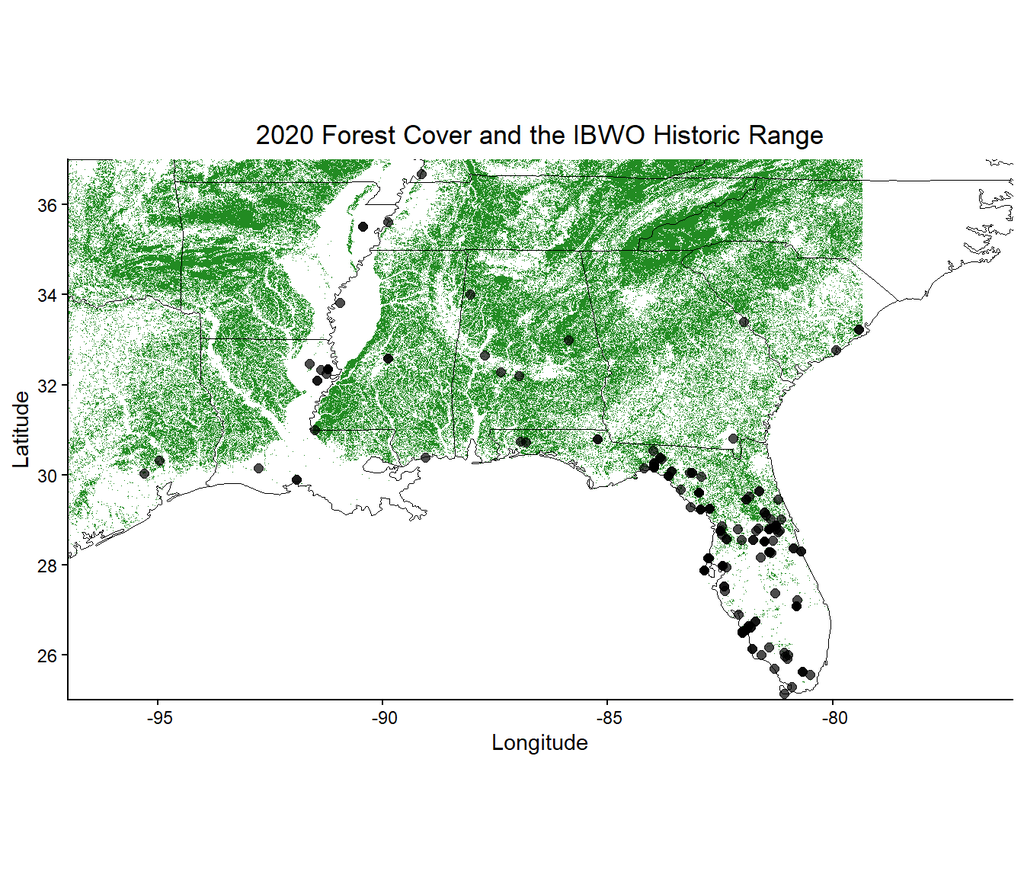

```r
nlcd_df <- as.data.frame(nlcd_lowres, xy = TRUE)
nlcd_df_forest <- nlcd_df %>%
  filter(landcover >= 1, landcover <= 6)

ggplot() +
  # Background: NLCD raster
  geom_raster(data = nlcd_df_forest, aes(x = x, y = y), fill = "forestgreen") +
  # State outlines
  geom_polygon(data = us, aes(x = long, y = lat, group = group),
               fill = NA, color = "black", size = 0.3) +
  # Species points
  geom_point(data = pilo.dismo, aes(x = lon, y = lat),
             color = "black", size = 2, alpha = 0.7) +
  coord_sf(xlim = c(-97,-76), ylim = c(25,37), expand = FALSE) +
  labs(title = "2020 Forest Cover and the IBWO Historic Range",
       x = "Longitude", y = "Latitude") +
  theme_classic() +
  theme(plot.title = element_text(hjust = 0.5))
```

Because the model predicted low occurrence probability at known occurrence points, I decided to explore how forest cover overlaps with the IBWO historic range. I gathered land cover data from Google Earth Engine and overlayed the IBWO historic range. The map shows forest cover in the US in 2020. The occurrence points and forest cover do not overlap as much as I had hoped. This could be because deforestation was a major cause for the drastic drop in the IBWO population. Comparing where forest cover was historically may provide better insight into the distribution of the IBWO.

If you are interested in exploring the most recent sightings and evidence you can find links below:

< [Rediscovery in Arkansas 2004 - article in Science](https://www.science.org/doi/10.1126/science.1114103)

< [Evidence of Survival 2024 - trail cameras](https://www.biorxiv.org/content/10.1101/2022.04.06.487399v1.full)

< [USFWS Comprehensive Species Description and Report](https://www.fws.gov/sites/default/files/documents/2024-04/921.pdf)